# Limpieza de Datos

Gestión de Datos - Sesión 2

Oscar Bustos

# Repaso

## Recordando…

- ¿Qué metodologías existen para los proyectos de minería de datos o de analítica de datos?
- ¿Por qué es necesario preparar los datos?
- ¿Por qué los datos tienen problemas?
- ¿Qué sucede si no se preparan los datos?
- ¿Qué actividades tiene el macro-proceso de preparación de datos?

## Tarea / Asignación

**Actividades a desarrollar:**

1. Leer capítulos 9 , 10 y 11 del libro *Hands-On Data Preprocessing in Python*.
2. Explorar el [Cuaderno de Google NotebookLM](https://notebook.google.com/notebook/e2719493-ad99-4abe-8f05-030eca72a7f9):
   - Revisar la infografía.
   - Realizar los quices incluidos.
   - Escuchar el podcast.

# Generalidades

## Metodología CRISP-DM

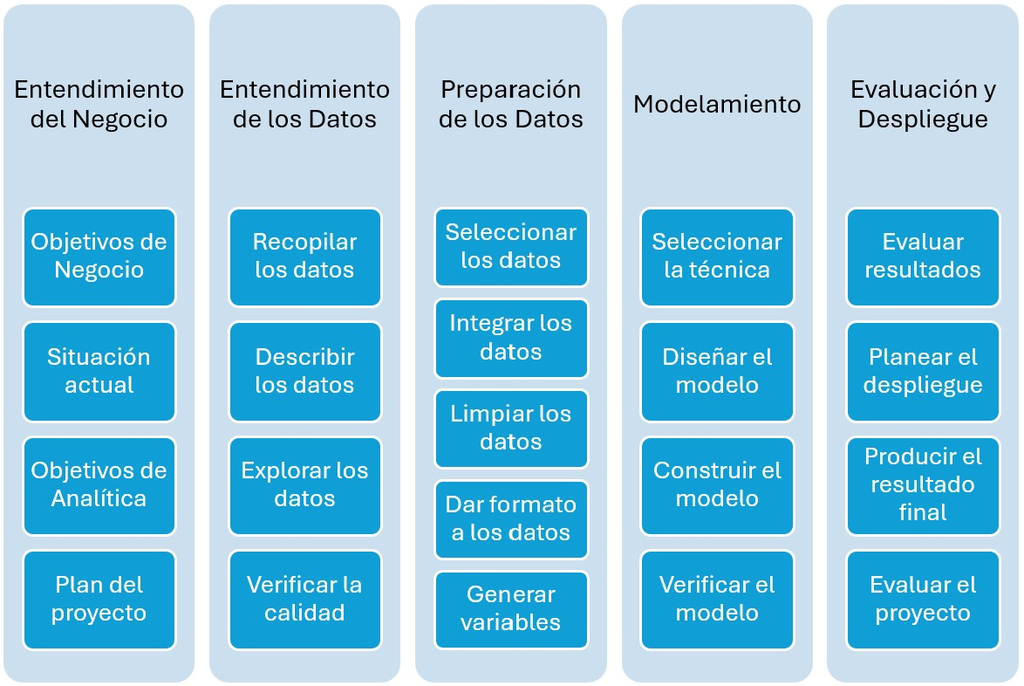

Actividades del proceso CRISP-DM

## Motivación: Calidad de Datos

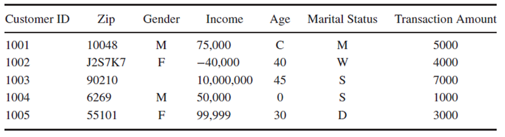

¿Qué problemas pueden encontrar en este DataSet?

## Motivación: Objetivos de Calidad

**Objetivos del Proceso:**

- **Datos útiles:** Obtener la mayor cantidad de datos de calidad para analítica.
- **Corrección:** Tratar inconsistencias, errores y datos irrelevantes.
- **Formato:** Adaptar la presentación de los datos para los modelos.

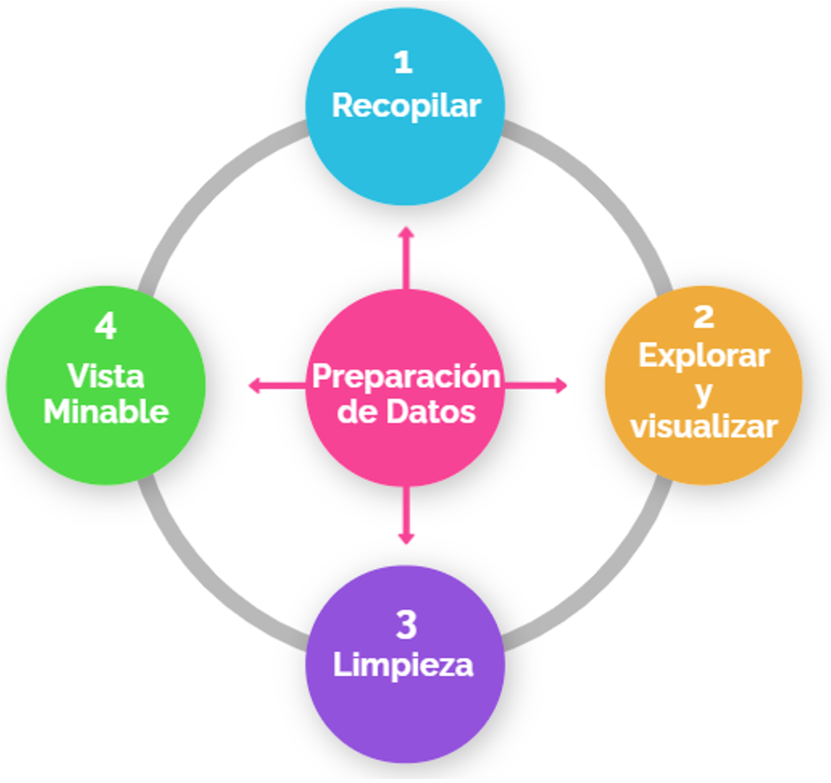

# Actividades limpieza de datos

## Actividades: Limpieza de Columnas

- Tratar columnas con valores únicos o nulos.
- Manejar alta cardinalidad (valores distintos).
- Eliminar sinónimos de la variable objetivo (fuga de datos).
- Eliminar columnas redundantes o correlacionadas.

## Actividades: Limpieza de Filas

- Tratar datos perdidos (missing values).
- Corregir inconsistencias y valores atípicos (outliers).
- Eliminar registros duplicados.

# Niveles de Limpieza

## Niveles de Limpieza de Datos

- **Nivel I (Estructura y Columnas):** Estructura base, índices y depuración de atributos.
- **Nivel II (Formato y Granularidad):** Transformación del contenedor y reformulación analítica.
- **Nivel III (Valores y Celdas):** Detección y corrección de nulos, outliers y errores.

## Nivel I: Limpieza de la Tabla

- **Enfoque:** Organización estructural y depuración de columnas (*macro*).
- **Estructura:** Formato estándar (DataFrame) e identificación única (índices).
- **Codificación:** Títulos intuitivos/cortos y diccionarios de columnas.
- **Depuración:** Eliminar columnas constantes, nulas totales o con fuga de datos.
- **Redundancia:** Tratar variables colineales ($|r| > 0.5$) o de alta cardinalidad.

## Ej. 1: Consolidación de Archivos

**¿Cómo analizar decenas de archivos sueltos?**

- Información dispersa y difícil de consultar en lote.
- Procesamiento manual inviable y propenso a errores.
- **Meta:** Unificar todo el contenido en una única tabla estructurada.

[figure not shown]

## Ej. 1: Consolidación de Archivos

Consolidar múltiples textos en un DataFrame:

```python
import pandas as pd
from os import listdir

archivos = listdir('Discursos/')
df = pd.DataFrame(index=range(len(archivos)), columns=['Archivo','Contenido'])
for i, nom in enumerate(archivos):
    with open('Discursos/' + nom, 'r') as f:
        df.loc[i] = [nom, f.read()]
```

## Ej. 2: Indexación Multinivel

Asignar múltiples columnas como índices para identificar de forma única e intuitiva las filas:

```python
# Eliminar columnas con valor único redundante
df_temp = df.drop(columns=['Anio'])

# Establecer índice multinivel
df_temp.set_index(['Mes', 'Dia', 'Hora'], inplace=True)

# Acceso rápido por índice
registro = df_temp.loc[2, 24, '00:30:00']
```

## Ej. 3: Diccionario de Columnas

Para encuestas con preguntas muy largas, se usan claves cortas (`Q1`..`Qn`) y un mapeo indexado:

```python
# Crear claves cortas y diccionario de mapeo
claves = [f'Q{i}' for i in range(1, 83)]
dic_columnas = pd.Series(df.columns, index=claves)

# Renombrar columnas para facilitar codificación
df.columns = claves

# Consultar la pregunta original
pregunta_4 = dic_columnas['Q4']
```

## Atributos con valores únicos

- **Mismo valor:** Todos los registros tienen idéntico valor (ej. Nacionalidad = Colombiana).
- **Valores nulos:** Mayoría de registros vacíos (ej. Cabina con 77.1% nulos).
- **Acción:** Eliminar la columna.

## Atributos discretos con valores diferentes

- **Alta cardinalidad:** Valores únicos o distintos por registro (ej. ID de pasajero, nombre, teléfono).
- **Acciones:**
  - Eliminar la columna si no tiene poder predictivo.
  - Ingeniería de características (ej. extraer Localidad o Ciudad a partir de la Dirección).

## Atributos Sinónimos / Fuga de Datos

- **Concepto:** Variables correlacionadas con el objetivo o no observables en la predicción real (fuga de datos).
- **Ejemplos:**
  - *Fecha de reparación* para predecir si se dañará.
  - *Edad de diagnóstico* para predecir si tiene diabetes.
  - *Número de fallecidos* para predecir si hay accidente grave.
- **Acción:** Eliminar la columna.

## Reto Titanic: Fuga de Datos

Un modelo de supervivencia alcanza un 99% de precisión al incluir la variable *Número de Bote Salvavidas*.

**Pregunta a la clase**

¿Por qué este modelo es inútil para la toma de decisiones?

**Respuesta**: Es fuga de datos (*data leakage*). Al comprar el boleto (momento de la predicción) no se sabe quién abordará un bote salvavidas.

## Atributos Redundantes: Concepto

**Colinealidad:** Ocurre cuando dos o más variables independientes están altamente correlacionadas.

**Coeficiente de Correlación de Pearson ($r$):**
$$r = \frac{\sum (x_i - \bar{x})(y_i - \bar{y})}{\sqrt{\sum (x_i - \bar{x})^2 \sum (y_i - \bar{y})^2}}$$

## Redundancia: Coeficiente de Pearson

- El coeficiente $r$ varía entre -1 y 1:
  - $r \approx 1$: Fuerte relación lineal positiva.
  - $r \approx -1$: Fuerte relación lineal negativa.
  - $r \approx 0$: Ausencia de correlación lineal.
- **Criterio de Colinealidad:**
  $$|r| > 0.5 \quad (\text{indica alta colinealidad})$$

## Detección de Redundancias

- **Problema:** Variables correlacionadas redundan en información.
- **Detección:** Matriz de correlación ($|r| > 0.5$).
- **Acción:** Eliminar uno de los atributos colineales.

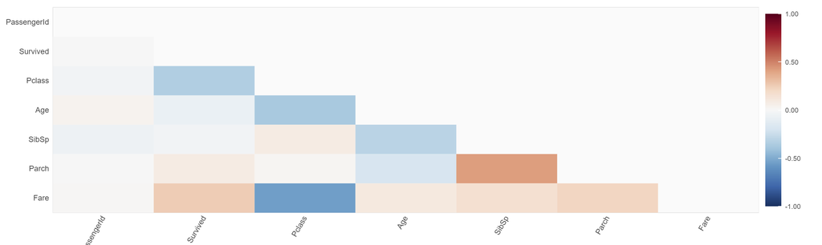

# Nivel II: Formato de la Tabla

## Nivel II: Formato y Granularidad

- **Enfoque:** Adaptación estructural según herramientas y modelos.
- **Reestructurar:** Transformar el contenedor (ej. DataFrame a Series con arrays).
- **Reformular:** Cambiar granularidad (ej. escala diaria a mensual o rezagos temporales).
- **Dependencia:** Guiado estrictamente por las metas y algoritmos del análisis.

## Ej. 1: Reestructurar para Boxplot

Para graficar boxplots de múltiples poblaciones, estructuramos los datos en un diccionario o `Series`:

```python
# Crear Series para almacenar arrays por clase (Churn)
churn_opc = df.Churn.unique()
box_sr = pd.Series('', index=churn_opc)

for opc in churn_opc:
    box_sr[opc] = df[df.Churn == opc].Fallas.values

# Graficar usando Matplotlib
plt.boxplot(box_sr, vert=False)
```

## Ej. 2: Reformulación para Predicción

Predecir demanda en mes $t$ requiriendo:

- **$IA_1$:** Promedio histórico del mismo mes.
- **$IA_2$:** Pendiente de regresión del mes.
- **$IA_3$:** Demanda promedio de meses $t-2$, $t-3$, $t-4$.

**Note**

A partir de un historial univariado, construimos una matriz con múltiples atributos explicativos.

## Código: Reformular Predicción

```python
# IA1: Promedio histórico del mismo mes
def comp_ia1(r):
    wdf = df.loc[:r.name].iloc[:-1]
    return wdf[wdf.Mes == r.name.month].Demanda.mean()

# IA3: Promedio de meses t-2, t-3 y t-4
def comp_ia3(r):
    wdf = df.loc[:r.name].iloc[-5:-2]
    return wdf.Demanda.mean()

pred_df['IA1'] = pred_df.apply(comp_ia1, axis=1)
pred_df['IA3'] = pred_df.apply(comp_ia3, axis=1)
```

# Nivel III: Evaluación y Corrección

## Nivel III: Valores y Datos

- **Enfoque:** Inspección y tratamiento celda por celda (*micro*).
- **Datos perdidos:** Diagnóstico de mecanismos (MCAR, MAR, MNAR) e imputación.
- **Valores atípicos:** Detección univariada (IQR) y multivariada (Clustering).
- **Tratamiento:** Imputación, *capping* (límites estadísticos) o eliminación.
- **Errores:** Corrección de inconsistencias y tipografías en registros.

## Datos Perdidos

- **Definición:** Ausencia de información para una variable en un registro (Missing Values).
- **Representación:** Celdas vacías, `NaN`, `NA`, `null`, `?` o ceros (`0`) anómalos.

## Tipos de Datos Perdidos

- **MCAR (Missing Completely at Random):** Pérdida sin razones sistemáticas (ej. falla de red aleatoria).
- **MAR (Missing at Random):** Pérdida sistemática ligada a otra variable observable (ej. alta velocidad causa falla del sensor).
- **MNAR (Missing Not at Random):** Pérdida sistemática ligada al valor perdido (ej. sensores adulterados por exceso de emisiones).

## Diagnóstico de Datos Perdidos

Se crea una variable oculta binaria ($1$ si es nulo, $0$ si no) y se analiza su relación con los otros atributos:

- **MCAR:** No hay relación significativa con otras variables.
- **MAR/MNAR:** Relación significativa con variables numéricas o categóricas.

## Diagnóstico: Atributos Numéricos

Se compara la distribución de variables numéricas entre registros nulos y no nulos.

- **Prueba Visual:** Boxplots e histogramas comparativos.
- **Prueba Estadística:** Test T de Student de dos muestras (`scipy.stats.ttest_ind`).
- **Interpretación:** Si $p\text{-value} > 0.05$, no hay diferencia significativa (MCAR compatible).

## Diagnóstico: Atributos Categóricos

Se compara la distribución de categorías para registros nulos y no nulos.

- **Prueba Visual:** Gráficos de barras comparativos.
- **Prueba Estadística:** Test Chi-cuadrado de independencia (`scipy.stats.chi2_contingency`).
- **Interpretación:** Si $p\text{-value} < 0.05$, existe una dependencia significativa (MAR/MNAR).

## Imputación Simple y Eliminación

- **Diagnóstico:** Evaluar criticidad y patrones con expertos.
- **Eliminar filas:** Cuando el porcentaje de registros perdidos es mínimo.
- **Eliminar columnas:** Cuando la variable es casi toda nula o no aporta valor.
- **Imputación univariada:** Media (simétrica), mediana (asimétrica) o moda.
- **Constante:** Rellenar con valor por defecto o categoría “Desconocido”.

## Imputación Avanzada

- **Por Grupo/Clase:** Usar media o mediana según segmentos de datos (ej. salario medio por cargo).
- **Deducción Lógica:** Inferir el valor usando reglas de negocio y otros atributos.
- **Modelos Predictivos:** Estimar valores faltantes usando algoritmos (ej. KNN, regresión).
- **Sin Alterar:** Dejar el nulo si el modelo lo permite (ej. XGBoost).

## Reto Titanic: Datos Faltantes

- **Problema:** La variable *Edad* tiene un 20% de datos faltantes.
- **Descarte de eliminación:** Perderíamos 1 de cada 5 pasajeros valiosos.
- **Descarte de media general:** Distorsiona la varianza y estructura de edades.
- **Solución:** Imputar la mediana agrupando por título (*Mr., Miss., Mrs., Master*).

## Datos Atípicos: Concepto

- **Definición:** Observaciones numéricas o categóricas que se desvían significativamente del comportamiento general.
- **Detección Visual:** Uso de gráficos de caja (boxplot), histogramas y diagramas de dispersión.

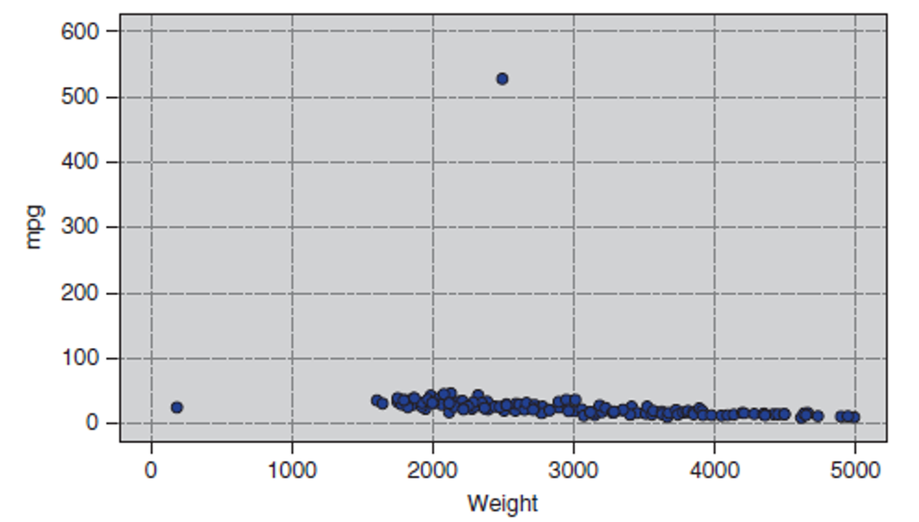

## Outliers: Método IQR

- **Rango Intercuartílico:** $\text{IQR} = Q_3 - Q_1$
- **Umbrales de Aceptación:**
  - Límite inferior: $L_I = Q_1 - 1.5 \times \text{IQR}$
  - Límite superior: $L_S = Q_3 + 1.5 \times \text{IQR}$
- **Identificación de Outliers:**
  $$x < L_I \quad \text{o} \quad x > L_S$$

## Niveles de Detección de Outliers

- **Univariada:** Rango intercuartílico IQR o frecuencias por categoría.
- **Bivariada (Num-Num):** Diagramas de dispersión (*scatter plot*).
- **Bivariada (Num-Cat):** Diagramas de cajas (*boxplots*) comparativos.
- **Bivariada (Cat-Cat):** Tablas de contingencia y mapas de calor.
- **Multivariada:** Algoritmos de agrupamiento (*clustering* con K-Means).

## Outliers: Detección Multivariada

Se utiliza clustering (**K-Means**) con diferentes valores de $k$ (ej. $2$ a $7$):

- **Criterio de Outliers:** Observaciones agrupadas en clústeres extremadamente pequeños (uno o pocos elementos).
- **Tratamiento por Capping (Tope):** Reemplazar los valores atípicos directamente por el límite estadístico (`lower_cap` o `upper_cap`) en lugar de eliminarlos.

## Guía de Tratamiento de Outliers

Reglas sugeridas por (Jafari 2022):

[figure not shown]

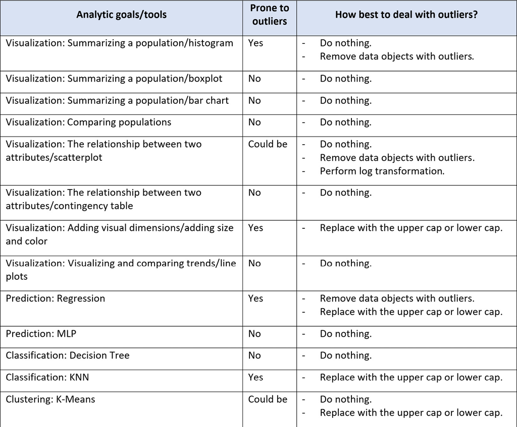

## Tratamiento de Outliers

- **Acciones posibles:**
  - **Ignorar:** Si la técnica es robusta (ej. modelos basados en árboles).
  - **Filtrar:** Eliminar registros atípicos.
  - **Imputar:** Reemplazar por límites, media o predicciones.
  - **Discretizar:** Convertir variables continuas a rangos discretos.

[figure not shown]

# Librerías en Python

## Pandas: Datos Faltantes

| **Método** | **Descripción** |
| --- | --- |
| `dropna()` | Elimina filas o columnas que contienen valores nulos. |
| `fillna()` | Rellena valores nulos con una constante o método de interpolación. |
| `isna()` | Devuelve máscara booleana indicando valores faltantes. |
| `notna()` | Negación de `isna()`, indica valores válidos (no nulos). |

## Pandas: Funciones de Limpieza

| **Método** | **Descripción** |
| --- | --- |
| `drop_duplicates()` | Elimina filas duplicadas del DataFrame. |
| `replace()` | Reemplaza valores específicos usando mapeos o regex. |
| `quantile()` | Calcula los cuantiles necesarios para el cálculo de IQR. |
| `corr()` | Genera la matriz de correlación (Pearson/Spearman). |

# Herramientas de Industria

## Arquitectura de Observabilidad

- **Concepto:** Monitorear y comprender la calidad, linaje y rendimiento de los datos en tiempo real.
- **Objetivo:** Detectar y resolver incidentes de calidad de forma proactiva.

[figure not shown]

## Dashboards de Observabilidad

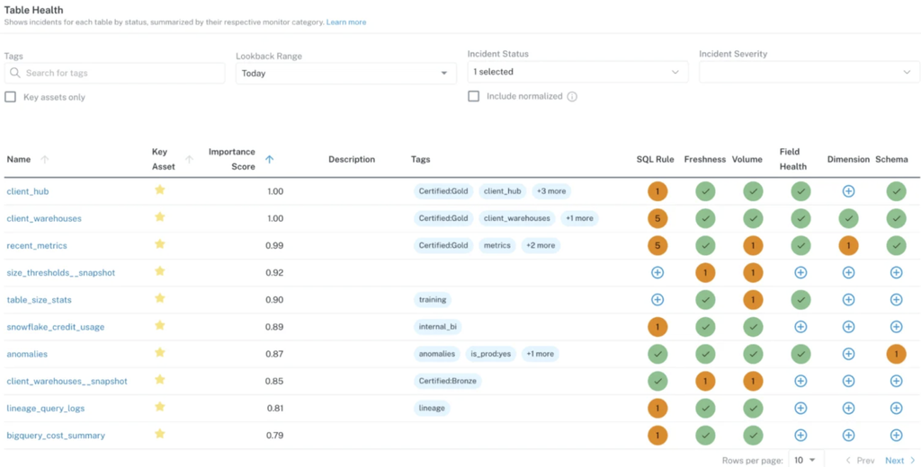

Dashboard de salud de datos en Monte Carlo

## Comparación de Herramientas

Comparación de herramientas de Data Observability

| **Herramienta** | **Ventajas** | **Desventajas** | **Costo** |
| --- | --- | --- | --- |
| [Monte Carlo](https://www.montecarlodata.com/) | Fácil integración, alertas en tiempo real, observabilidad total. | Alta complejidad de configuración inicial. | Alto |
| [Great Expectations](https://greatexpectations.io/) | Open-source, altamente personalizable, validaciones robustas. | Curva de aprendizaje alta, sin alertas nativas. | Gratis |
| [Databand](https://www.ibm.com/es-es/products/databand) | Excelente monitoreo/alertas, integración con Airflow. | Comunidad pequeña, menor número de conectores. | Medio |
| [Bigeye](https://www.bigeye.com/) | Configuración rápida, métricas de calidad automatizadas. | Poca personalización de reglas complejas. | Alto |

## Referencias

Jafari, Roy. 2022. *Hands-on Data Preprocessing in Python: Learn How to Effectively Prepare Data for Successful Data Analytics*. Packt Publishing Ltd.

McKinney, Wes. 2022. *Python for Data Analysis*. " O’Reilly Media, Inc.".

Oluleye, Ayodele. 2023. *Exploratory Data Analysis with Python Cookbook: Over 50 Recipes to Analyze, Visualize, and Extract Insights from Structured and Unstructured Data*. Packt Publishing Ltd.

Provost, Foster, and Tom Fawcett. 2013. *Data Science for Business: What You Need to Know about Data Mining and Data-Analytic Thinking*. " O’Reilly Media, Inc.".